# Topic Modeling of COVID-19 Open Research Dataset

## - Finding Business topics for publications on COVID-19

Since the COVID-19 pandemic, academic society has published many papers about COVID-19, SARS-CoV-2, and related coronaviruses. The Allen Institute for AI prepared the COVID-19 Open Research Dataset (CORD-19), a resource of over 200,000 scholarly articles, including over 100,000 with full text, about COVID-19, SARS-CoV-2, and related coronaviruses.

The objective of this code is to use the latent Dirichlet allocation (LDA), a popular text mining method for topic modeling, to find business insight in the massive amount of publications on COVID-19.

I will explore the following questions.

- What do we know about business topics associate with COVID-19?
- What do we know about the topics that combine business and biology, or business and health care?
- What has been published about information sharing and management?
- What has been published about social science that may impact business?

```python
import pandas as pd
import matplotlib.pyplot as plt
import pyLDAvis.gensim
import re
import nltk
from nltk.stem.porter import *
from stop_words import get_stop_words
from nltk.tokenize import word_tokenize
from wordcloud import WordCloud
import gensim
from gensim import corpora, models
import pickle

%matplotlib inline
```

# 1. Read dataset.

Read metadata.csv downloaded from https://www.kaggle.com/allen-institute-for-ai/CORD-19-research-challenge

```python
meta = pd.read_csv("../metadata.csv")
print(meta.shape)
meta.head()
```

```
(341713, 19)
```

|  | cord_uid | sha | source_x | title | doi | pmcid | pubmed_id | license | abstract | publish_time | authors | journal | mag_id | who_covidence_id | arxiv_id | pdf_json_files | pmc_json_files | url | s2_id |
| --- | --- | --- | --- | --- | --- | --- | --- | --- | --- | --- | --- | --- | --- | --- | --- | --- | --- | --- | --- |
| 0 | ug7v899j | d1aafb70c066a2068b02786f8929fd9c900897fb | PMC | Clinical features of culture-proven Mycoplasma... | 10.1186/1471-2334-1-6 | PMC35282 | 11472636 | no-cc | OBJECTIVE: This retrospective chart review des... | 2001-07-04 | Madani, Tariq A; Al-Ghamdi, Aisha A | BMC Infect Dis | NaN | NaN | NaN | document_parses/pdf_json/d1aafb70c066a2068b027... | document_parses/pmc_json/PMC35282.xml.json | https://www.ncbi.nlm.nih.gov/pmc/articles/PMC3... | NaN |
| 1 | 02tnwd4m | 6b0567729c2143a66d737eb0a2f63f2dce2e5a7d | PMC | Nitric oxide: a pro-inflammatory mediator in l... | 10.1186/rr14 | PMC59543 | 11667967 | no-cc | Inflammatory diseases of the respiratory tract... | 2000-08-15 | Vliet, Albert van der; Eiserich, Jason P; Cros... | Respir Res | NaN | NaN | NaN | document_parses/pdf_json/6b0567729c2143a66d737... | document_parses/pmc_json/PMC59543.xml.json | https://www.ncbi.nlm.nih.gov/pmc/articles/PMC5... | NaN |
| 2 | ejv2xln0 | 06ced00a5fc04215949aa72528f2eeaae1d58927 | PMC | Surfactant protein-D and pulmonary host defense | 10.1186/rr19 | PMC59549 | 11667972 | no-cc | Surfactant protein-D (SP-D) participates in th... | 2000-08-25 | Crouch, Erika C | Respir Res | NaN | NaN | NaN | document_parses/pdf_json/06ced00a5fc04215949aa... | document_parses/pmc_json/PMC59549.xml.json | https://www.ncbi.nlm.nih.gov/pmc/articles/PMC5... | NaN |
| 3 | 2b73a28n | 348055649b6b8cf2b9a376498df9bf41f7123605 | PMC | Role of endothelin-1 in lung disease | 10.1186/rr44 | PMC59574 | 11686871 | no-cc | Endothelin-1 (ET-1) is a 21 amino acid peptide... | 2001-02-22 | Fagan, Karen A; McMurtry, Ivan F; Rodman, David M | Respir Res | NaN | NaN | NaN | document_parses/pdf_json/348055649b6b8cf2b9a37... | document_parses/pmc_json/PMC59574.xml.json | https://www.ncbi.nlm.nih.gov/pmc/articles/PMC5... | NaN |
| 4 | 9785vg6d | 5f48792a5fa08bed9f56016f4981ae2ca6031b32 | PMC | Gene expression in epithelial cells in respons... | 10.1186/rr61 | PMC59580 | 11686888 | no-cc | Respiratory syncytial virus (RSV) and pneumoni... | 2001-05-11 | Domachowske, Joseph B; Bonville, Cynthia A; Ro... | Respir Res | NaN | NaN | NaN | document_parses/pdf_json/5f48792a5fa08bed9f560... | document_parses/pmc_json/PMC59580.xml.json | https://www.ncbi.nlm.nih.gov/pmc/articles/PMC5... | NaN |

Check the variable names of the dataset.

```python
print(meta.columns)
```

```
Index(['cord_uid', 'sha', 'source_x', 'title', 'doi', 'pmcid', 'pubmed_id',
       'license', 'abstract', 'publish_time', 'authors', 'journal', 'mag_id',
       'who_covidence_id', 'arxiv_id', 'pdf_json_files', 'pmc_json_files',
       'url', 's2_id'],
      dtype='object')
```

Filter meta file by selecting only papers after 2020.

```python
meta["publish_time"] = pd.to_datetime(meta["publish_time"])
meta["publish_year"] = pd.DatetimeIndex(meta['publish_time']).year
meta["publish_month"] = pd.DatetimeIndex(meta['publish_time']).month
meta["publish_day"] = pd.DatetimeIndex(meta['publish_time']).day
meta = meta[meta["publish_year"] == 2020]
print(meta.shape[0], " papers are available after 2020 Jan 1.")
```

```
247255  papers are available after 2020 Jan 1.
```

Plot publication numbers in each month of 2020.

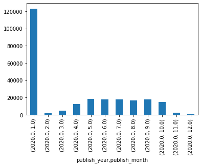

```python
meta.groupby(["publish_year","publish_month"]).size().plot.bar()
```

- It is strange that most papers are published in the first month of 2020. I plot the publication numbers in each day of 2020 Jan..

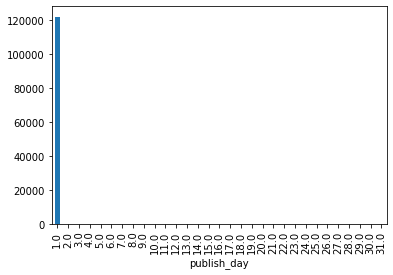

```python
meta[(meta.publish_year==2020)&(meta.publish_month==1)].groupby(["publish_day"]).size().plot.bar()
```

- Most papers are published in Jan. 1st, 2020.
- I guess most papers in the dataset don't have exact publishing date and have benn marked 1/1/2020.

Create dataframe with all abstracts and use it as input corpus.

- Papers without abstract are dropped.

```python
index = []
for i in range(len(meta)):
    if type(meta.iloc[i, 8]) != float:
        index.append(i)
docs = meta.iloc[index, 8]
print(docs.shape[0], "abstracts are collected.")
```

```
163820 abstracts are collected.
```

Document number is high. I sample 50,000 documents for reducing computing time.

```python
samp_size = 50000 #Here, the size can be changed.
samp_docs = docs.sample(n=samp_size,random_state=100)
samp_docs = samp_docs.reset_index(drop=True)
samp_docs.head()
```

```
0    BACKGROUND: Different skin manifestations of C...
1    SARS-CoV-2 is the cause of the worldwide outbr...
2    BACKGROUND: Multiple professional bodies have ...
3    Severe cases of COVID-19 are characterized by ...
4    The COVID-19 pandemic caused by the SARS-CoV-2...
Name: abstract, dtype: object
```

# 2. Preprocessing texts

Sentence level preprocess

- Lowercase + base filter
- Some basic normalization

```python
def preprocess_sent(docs):
    """
    Get sentence level preprocessed data from raw texts
    :param rw: review to be processed
    :return: sentence level pre-processed review
    """
    # Add missing delimiter: xxxThis is a --> xxx.
    s = re.sub(r'([a-z])([A-Z])', r'\1\. \2', docs)  # before lower case
    # Make words all lower case.
    s = s.lower()
    # Remove < and >
    s = re.sub(r'&gt|&lt', ' ', s)
    # Remove letters that repeat more than 2 time.
    s = re.sub(r'([a-z])\1{2,}', r'\1', s)
    # Remove non-word characters that repeat more than 1 time.
    s = re.sub(r'([\W+])\1{1,}', r'\1', s)
    # Use string * as delimiter
    s = re.sub(r'\*|\W\*|\*\W', '. ', s)
    # Remove words in parenthesis, which are assumed less informal
    s = re.sub(r'\(.*?\)', '. ', s)
    # xxx[?!]. -- > xxx.
    s = re.sub(r'\W+?\.', '.', s)
    # [.?!]xxx --> [.?!] xxx
    s = re.sub(r'(\.|\?|!)(\w)', r'\1 \2', s)
    return s.strip()

text_lists = [preprocess_sent(text) for text in samp_docs]
```

Word level preprocess

```python
# define stemmer

p_stemmer = PorterStemmer()
# create stop words list
stop_words = (list(
    set(get_stop_words('en'))
    |set(get_stop_words('es'))
    |set(get_stop_words('de'))
    |set(get_stop_words('it'))
    |set(get_stop_words('ca'))
    |set(get_stop_words('pt'))
    |set(get_stop_words('pl'))
    |set(get_stop_words('da'))
    |set(get_stop_words('ru'))
    |set(get_stop_words('sv'))
    |set(get_stop_words('sk'))
    |set(get_stop_words('nl'))
    |set(["abstract","d","background", "methods", "results", "conclusion"])
))
```

```python
def preprocess_word(s):
    """
    Get word level preprocessed data from preprocessed sentences
    including: remove punctuation, select noun, stem, stop_words
    :param s: sentence to be processed
    :return: word level pre-processed documents
    """
    if not s:
        return None
    w_list = word_tokenize(s)
    w_list = [word for word in w_list if word.isalpha()]
    w_list = [word for (word, pos) in nltk.pos_tag(w_list) if pos[:2] == 'NN']
    w_list = [word for word in w_list if word not in stop_words]
    w_list = [p_stemmer.stem(word) for word in w_list]

    return w_list

token_lists = [preprocess_word(text) for text in text_lists]
```

Put abstract and token list together. In later on steps, the abstracts are used to demenstrate topics.

- Empty token lists are removed.

```python
docs_token = [(samp_docs.iloc[i], token_lists[i]) for i in range(len(samp_docs)) if token_lists[i] != []]
samp_pd = pd.DataFrame.from_records(docs_token, columns=['Abstract','Token'])
token_lists = samp_pd.Token.to_list()
samp_pd.head()
# samp_pd.to_pickle("./samp_pd.pkl")
```

|  | Abstract | Token |
| --- | --- | --- |
| 0 | BACKGROUND: Different skin manifestations of C... | [manifest, lesion, hand, feet, chilblain, inci... |
| 1 | SARS-CoV-2 is the cause of the worldwide outbr... | [caus, outbreak, report, decemb, case, death, ... |
| 2 | BACKGROUND: Multiple professional bodies have ... | [bodi, recommend, diabet, criteria, fast, gluc... |
| 3 | Severe cases of COVID-19 are characterized by ... | [case, inflammatori, process, failur, death, i... |
| 4 | The COVID-19 pandemic caused by the SARS-CoV-2... | [pandem, viru, ten, thousand, death, spain, he... |

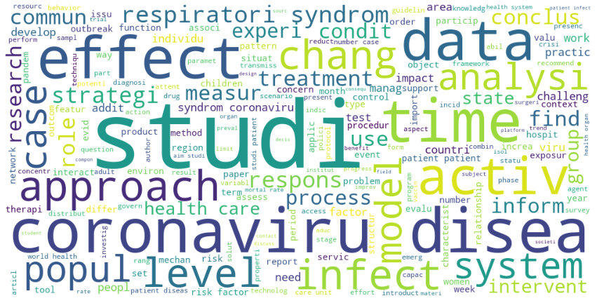

```python
unique_string=" ".join([ " ".join(tl) for tl in token_lists])
wordcloud = WordCloud(width = 1000, height = 500, background_color='white').generate(unique_string)
plt.figure(figsize=(15,8))
plt.imshow(wordcloud)
plt.axis("off")
plt.savefig("word_cloud"+".png", bbox_inches='tight')
plt.show()
plt.close()
```

# 4. Define model object

```python
# create dictionary from token lists.
dictionary = corpora.Dictionary(token_lists)
# convert tokenized documents into a document-term matrix
corpus = [dictionary.doc2bow(text) for text in token_lists]

pickle.dump(corpus, open('corpus.pkl', 'wb'))
dictionary.save('dictionary.gensim')
```

```python
def create_lda(corp, dict, ntopic, saved_file_name):
    """
    A function to create LDA model.
    :param corp: document-term matrix created from token_lists.
    :param dict: dictionary created from token lists.
    :param ntopic: number of topics.
    :param saved_file_name: the file name for saving the LDA model.
    :return
    """
    model = gensim.models.ldamodel.LdaModel(corp,
                                           num_topics=ntopic,
                                           random_state=66,
                                           id2word=dict , passes=20)
    model.save(saved_file_name)
    return model

lda_model = create_lda(corp=corpus, dict=dictionary, ntopic=100, saved_file_name="LDA_model.gensim")
```

```python
# Load data and model.

# samp_pd = pd.read_pickle("samp_pd.pkl")
# dictionary = gensim.corpora.Dictionary.load('dictionary.gensim')
# corpus = pickle.load(open('corpus.pkl', 'rb'))
# lda_model = gensim.models.ldamodel.LdaModel.load("LDA_model.gensim")
```

# 5. Post-analysis

Print topics as keywords.

```python
for topic in lda_model.print_topics(num_topics=100):
    print(topic)
```

```
(0, '0.088*"anxieti" + 0.071*"stress" + 0.055*"depress" + 0.053*"life" + 0.041*"symptom" + 0.041*"studi" + 0.039*"health" + 0.035*"qualiti" + 0.027*"scale" + 0.027*"distress"')
(1, '0.128*"theori" + 0.083*"code" + 0.063*"intent" + 0.050*"nutrit" + 0.049*"prone" + 0.040*"substitut" + 0.033*"subtyp" + 0.033*"repeat" + 0.033*"reveal" + 0.032*"frame"')
(2, '0.178*"risk" + 0.110*"factor" + 0.080*"mortal" + 0.052*"diseas" + 0.028*"diabet" + 0.025*"outcom" + 0.025*"regress" + 0.024*"age" + 0.023*"comorbid" + 0.021*"studi"')
(3, '0.186*"rate" + 0.074*"year" + 0.073*"popul" + 0.067*"age" + 0.062*"incid" + 0.059*"preval" + 0.040*"studi" + 0.035*"proport" + 0.028*"data" + 0.020*"differ"')
(4, '0.059*"polici" + 0.043*"crisi" + 0.041*"govern" + 0.040*"food" + 0.034*"pandem" + 0.027*"countri" + 0.024*"impact" + 0.024*"respons" + 0.022*"resourc" + 0.019*"capac"')
(5, '0.124*"energi" + 0.113*"space" + 0.066*"transfer" + 0.064*"complex" + 0.063*"task" + 0.063*"forc" + 0.061*"movement" + 0.048*"build" + 0.033*"heat" + 0.032*"occup"')
(6, '0.217*"medicin" + 0.109*"devic" + 0.085*"medic" + 0.051*"law" + 0.046*"methodolog" + 0.044*"pharmaci" + 0.041*"promot" + 0.040*"pharmacist" + 0.032*"list" + 0.032*"hepat"')
(7, '0.344*"control" + 0.076*"concentr" + 0.045*"studi" + 0.033*"extract" + 0.029*"effect" + 0.029*"stabil" + 0.028*"formul" + 0.027*"brazil" + 0.026*"muscl" + 0.025*"migrat"')
(8, '0.100*"exercis" + 0.090*"impair" + 0.080*"post" + 0.053*"subset" + 0.047*"trajectori" + 0.046*"rest" + 0.042*"pair" + 0.036*"caution" + 0.035*"cent" + 0.034*"ingredi"')
(9, '0.147*"resist" + 0.112*"h" + 0.074*"convers" + 0.068*"antibiot" + 0.043*"aki" + 0.039*"pd" + 0.025*"certainti" + 0.024*"cognit" + 0.022*"fluctuat" + 0.017*"immunomodulatori"')
(10, '0.209*"person" + 0.086*"restrict" + 0.066*"resili" + 0.053*"korea" + 0.036*"messag" + 0.031*"cooper" + 0.025*"municip" + 0.025*"epicent" + 0.023*"gather" + 0.022*"pacient"')
(11, '0.123*"volum" + 0.120*"pain" + 0.073*"panel" + 0.064*"fluid" + 0.047*"radiat" + 0.036*"formula" + 0.036*"inject" + 0.032*"arteri" + 0.031*"nerv" + 0.023*"identifi"')
(12, '0.152*"worker" + 0.130*"staff" + 0.117*"resid" + 0.091*"work" + 0.041*"satisfact" + 0.035*"employe" + 0.030*"member" + 0.026*"safeti" + 0.026*"personnel" + 0.025*"wast"')
(13, '0.178*"function" + 0.152*"effect" + 0.073*"mechan" + 0.050*"properti" + 0.032*"condit" + 0.031*"plant" + 0.030*"modul" + 0.029*"signal" + 0.023*"studi" + 0.021*"alter"')
(14, '0.288*"drug" + 0.069*"agent" + 0.033*"diseas" + 0.029*"develop" + 0.027*"discoveri" + 0.027*"use" + 0.026*"treatment" + 0.020*"biolog" + 0.020*"review" + 0.019*"approach"')
(15, '0.076*"speci" + 0.067*"anim" + 0.063*"human" + 0.062*"pathogen" + 0.044*"dna" + 0.036*"divers" + 0.031*"skin" + 0.028*"bacteria" + 0.017*"polymorph" + 0.016*"virul"')
(16, '0.168*"posit" + 0.136*"hand" + 0.084*"gender" + 0.057*"hygien" + 0.035*"zone" + 0.034*"race" + 0.030*"word" + 0.029*"dentist" + 0.029*"mm" + 0.027*"sanit"')
(17, '0.085*"choic" + 0.081*"patholog" + 0.079*"rehabilit" + 0.072*"modal" + 0.071*"shift" + 0.056*"traine" + 0.045*"expect" + 0.039*"intak" + 0.038*"board" + 0.038*"updat"')
(18, '0.398*"cancer" + 0.184*"phase" + 0.041*"transit" + 0.039*"oncolog" + 0.029*"chemotherapi" + 0.021*"survivor" + 0.017*"norm" + 0.017*"priorit" + 0.016*"separ" + 0.013*"mexico"')
(19, '0.204*"commun" + 0.091*"program" + 0.075*"home" + 0.040*"barrier" + 0.038*"interview" + 0.027*"experi" + 0.024*"team" + 0.020*"error" + 0.017*"prefer" + 0.017*"leadership"')
(20, '0.116*"case" + 0.094*"number" + 0.063*"countri" + 0.058*"death" + 0.043*"data" + 0.024*"rate" + 0.019*"growth" + 0.019*"time" + 0.018*"march" + 0.015*"pandem"')
(21, '0.087*"citi" + 0.080*"pattern" + 0.072*"air" + 0.056*"locat" + 0.055*"mobil" + 0.051*"pollut" + 0.049*"area" + 0.032*"matter" + 0.029*"intens" + 0.028*"behaviour"')
(22, '0.325*"children" + 0.197*"famili" + 0.054*"adult" + 0.046*"parent" + 0.038*"child" + 0.026*"year" + 0.020*"age" + 0.019*"pictur" + 0.016*"complet" + 0.014*"smartphon"')
(23, '0.171*"manag" + 0.091*"recommend" + 0.076*"guidelin" + 0.038*"practic" + 0.037*"risk" + 0.036*"guidanc" + 0.029*"societi" + 0.028*"clinician" + 0.024*"strategi" + 0.021*"evid"')
(24, '0.333*"chang" + 0.087*"organ" + 0.040*"world" + 0.033*"climat" + 0.021*"foundat" + 0.021*"phenomenon" + 0.019*"scientist" + 0.018*"rise" + 0.018*"idea" + 0.018*"trade"')
(25, '0.120*"research" + 0.023*"field" + 0.021*"develop" + 0.020*"articl" + 0.018*"pandem" + 0.017*"challeng" + 0.015*"issu" + 0.015*"paper" + 0.014*"perspect" + 0.014*"experi"')
```

[output cut: 74 more lines]

The Dominant topic and its percentage contribution in each document

```python
def dominant_topic(ldamodel, corp, texts, saved_file_name):
    """
    Determine the dominant topic and its percentage contribution in each documents.
    :param ldamodel: LDA model.
    :param corp: corpus.
    :param texts: Documents.
    :param saved_file_name: The file name for saving the dataframe.
    :return: A dataframe having the dominant topic, topic percentage contribution, keywords, and Abstract.
    """
    topic_df = pd.DataFrame()
    for i, row_list in enumerate(ldamodel[corp]):
        row = row_list[0] if ldamodel.per_word_topics else row_list
        row = sorted(row, key=lambda x: (x[1]), reverse=True)
        if row:
            topic_num,prop_topic = row[0]
            topic_keywords = ", ".join([word for word, prop in ldamodel.show_topic(topic_num)])
            topic_df = topic_df.append(pd.Series([int(topic_num), round(prop_topic,4), topic_keywords]), ignore_index=True)
        else:
           topic_df = topic_df.append(pd.Series([10000, round(0.0,4), ""]), ignore_index=True)
    topic_df = pd.concat([topic_df, texts], axis=1)
    topic_df.columns = ['Dominant_Topic', 'Topic_Perc_Contrib', 'Keywords', 'Abstract']
    topic_df.to_pickle(saved_file_name)
    return topic_df

text_topic_df = dominant_topic(ldamodel=lda_model, corp=corpus, texts=samp_pd.Abstract,saved_file_name="text_topics.pkl")
text_topic_df.head(3)
```

|  | Dominant_Topic | Topic_Perc_Contrib | Keywords | Abstract |
| --- | --- | --- | --- | --- |
| 0 | 72.0 | 0.1849 | case, symptom, patient, present, fever, manife... | BACKGROUND: Different skin manifestations of C... |
| 1 | 20.0 | 0.1750 | case, number, countri, death, data, rate, grow... | SARS-CoV-2 is the cause of the worldwide outbr... |
| 2 | 7.0 | 0.3146 | control, concentr, studi, extract, effect, sta... | BACKGROUND: Multiple professional bodies have ... |

Find the most representative abstract for each topic

```python
# comment this code block in the first run.
# Load previously created data and model.

samp_pd = pd.read_pickle("samp_pd.pkl")
dictionary = gensim.corpora.Dictionary.load('dictionary.gensim')
corpus = pickle.load(open('corpus.pkl', 'rb'))
lda_model = gensim.models.ldamodel.LdaModel.load("LDA_model.gensim")
text_topic_df = pickle.load(open("text_topics.pkl", 'rb'))
```

```python
def show_topic(text_topic, topic_num, first_n_abstract):
    """
    Show a topic using representative abstracts.
    :param text_topic: a dateframe with topic percentage contribution of each abstract.
    :param topic_num: the topic number.
    :param first_n_abstract: the number of the abstract to be shown.
    """
    topic_group = text_topic_df[text_topic_df["Dominant_Topic"] == topic_num]
    topic_group = topic_group.sort_values(['Topic_Perc_Contrib'], ascending=False)
#     print("Topic ", topic_num)
    cloud = WordCloud(
                  background_color='white',
                  width=2500,
                  height=1500,
                  colormap='tab10',
                  prefer_horizontal=1.0
                  )
    cloud.generate_from_frequencies(dict(lda_model.show_topic(topic_num, topn=30)), max_font_size=300)
    plt.figure(figsize=(8, 5.6), facecolor=None)
    plt.imshow(cloud, interpolation='bilinear')
    plt.title('Topic ' + str(topic_num+1), fontdict=dict(size=16))
    plt.axis("off")
    plt.show()
    print("Keywords", topic_group["Keywords"].iloc[0])
    for i in range(first_n_abstract):
        print(topic_group["Abstract"].iloc[i])
        print(topic_group['Topic_Perc_Contrib'].iloc[i])
```

# 6. Topics with Business Insights

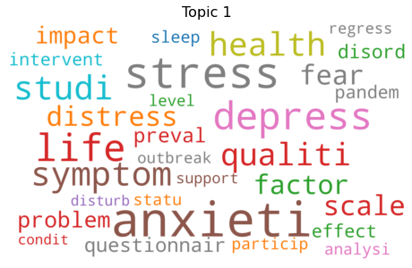

```
Keywords anxieti, stress, depress, life, symptom, studi, health, qualiti, scale, distress
BACKGROUND: It is well known that unexpected pandemic has led to an increase in mental health problems among a variety of populations. METHODS: In this study, an online non-probability sample survey was used to anonymously investigate the anxiety and depression symptoms among medical staff under the…
0.7347000241279602
```

```python
show_topic(text_topic_df, 0,1)
```

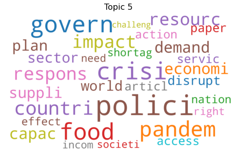

```
Keywords polici, crisi, govern, food, pandem, countri, impact, respons, resourc, capac
The multiple faces of the Coronavirus Disease 2019 (COVID-19), also included the impact on the economy. As a consequence of the significant life and society disruption, multiple implications are derived from the COVID-19 crisis and pandemic, including a significant backward on the economy. In the cu…
0.6585000157356262
During the Covid-19 global pandemic, and in the face of an imminent crisis derived from it, various concerns arise regarding the economic consequences that the situation will bring, as well as whether the response of the different governments will be enough in the long term. The Foundational Economy…
0.6553999781608582
If farmers expect society to help protect them against the crushing effect of surpluses, they must be prepared to protect society by working out permanent arrangements for storing of reserve food supplies. Both farmers and non-farmers have a responsibility to each other, and any dodging of this resp…
0.6463000178337097
COVID-19 has created high transaction costs and uncertainty in India's transformed food supply chains, putting food security at risk as 92% of food consumption in India is purchased, predominantly from the private sector Government faces the challenge of marshalling resources between mitigating the …
0.635699987411499
The COVID-19 pandemic has disrupted the global food supply chain and exacerbated the problem of food and nutritional insecurity
0.6262999773025513
COVID-19 has created challenges and opportunities for the technology sector, and companies are grappling with how to address them The effects of the pandemic do not fit into a single category
0.6262000203132629
```

```python
show_topic(text_topic_df, 4,6)
```

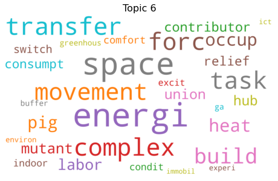

```
Keywords energi, space, transfer, complex, task, forc, movement, build, heat, occup
The major light-harvesting complex of photosystem II (LHCII) is the main contributor to sunlight energy harvesting in plants. The flexible design of LHCII underlies a photoprotective mechanism whereby this complex switches to a dissipative state in response to high light stress, allowing the rapid d…
0.36169999837875366
Across industries, labor activism and unionism has emerged as a powerful force from the crisis of COVID-19 to advocate for job security, workplace safety, and public policy. However, social workers have largely not participated in this movement. In order to better represent social worker interests, …
0.3361999988555908
Energy efficiency, indoor environmental quality, and comfort in public buildings has received increasing attention in recent years as it can contribute to maintaining safety conditions and to the reduction of conventional fuels consumption, energy costs for building owners, and greenhouse gas emissi…
0.3158999979496002
Decoupling energy consumption from economic growth is vital to the realization of sustainable development. To reduce energy demand, China has implemented an energy cap policy and pledged to limit total energy consumption to around 5000 million tons of standard coal equivalent by 2020 in the 13th Fiv…
0.30320000648498535
‘Energy efficiency first’ is one of the key principles of the Energy Union, mainly due to it being the most cost eﬀective way to reduce emissions, improving energy security, enhancing competitiveness and making energy consumption more aﬀordable for all consumers In light of the revised EU Energy Eff…
0.29510000348091125
Verification algorithms are among the most resource-intensive computation tasks. Saving energy is important for our living environment and to save cost in data centers. Yet, researchers compare the efficiency of algorithms still in terms of consumption of CPU time (or even wall time). Perhaps one re…
0.2847999930381775
```

```python
show_topic(text_topic_df, 5,6)
```

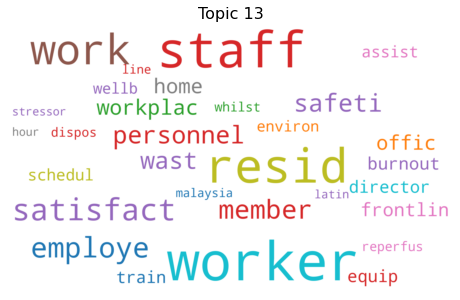

```
Keywords worker, staff, resid, work, satisfact, employe, member, safeti, personnel, wast
The COVID-19 pandemic has underscored the essential role of public safety personnel in serving and protecting all Canadians. Public safety personnel were reporting challenges with mental health and well-being before the COVID-19 pandemic; accordingly, the new stressors may mean public safety personn…
0.460099995136261
The coronavirus disease 2019 (COVID-19) pandemic has posed significant changes to resident education and workflow. However, the impact of the pandemic on U.S. neurosurgery residents has not been well characterized. We investigated the impact of the COVID-19 pandemic on U.S. neurosurgery resident wor…
0.4203000068664551
• The COVID-19 pandemic may put the mental wellbeing of trainees at risk. • Hopelessness, helplessness and burnout are important to be aware of. • We need to foster an open culture of trust and support. • We need to promote resilience in colleagues/trainees where possible.
0.4174000024795532
```

```python
show_topic(text_topic_df, 12,3)
```

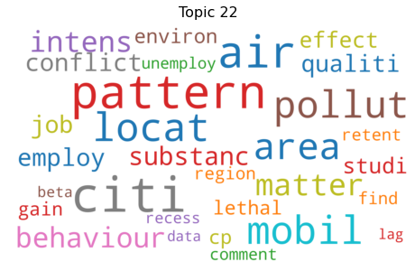

```
Keywords citi, pattern, air, locat, mobil, pollut, area, matter, intens, behaviour
We construct a new measure of the aggressiveness of COVID-19 policies in 75 Canadian and American cities and estimate the effect of these policies on mobility patterns in each city Using a new dataset of five municipal COVID-19 policy indicators for each of our 75 cities, combined with 11 provincial…
0.4912000000476837
Using transboundary pollution from mainland China as an instrument, we show that air pollution leads to higher cardio-respiratory mortality in Hong Kong. However, the air pollution effect has dramatically decreased over the past two decades: before 2003, a 10-unit increase in the Air Pollution Index…
0.38999998569488525
The present work aims to investigate seasonal variations in air pollution levels in Lucknow and assess the ambient air quality of the city together with highlighting the health impacts of major pollutants like PM10, PM2.5, SO2, NO2, Pb, Ni and aerosols from 2010 to 2019. The maximum and minimum valu…
0.3815999925136566
```

```python
show_topic(text_topic_df, 21,3)
```

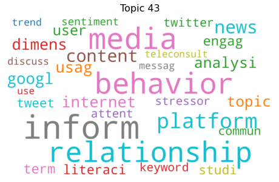

```
Keywords inform, media, behavior, relationship, platform, news, content, googl, internet, dimens
Pre-print servers have helped to rapidly publish important information during the COVID-19 pandemic. The downside is the risk of spreading false information or fake news though.
0.6019999980926514
Pre-print servers have helped to rapidly publish important information during the COVID-19 pandemic. The downside is the risk of spreading false information or fake news though.
0.6019999980926514
The COVID-19 pandemic has produced a flurry of online activity on social media sites. As such, analysis of social media data during the COVID-19 pandemic can produce unique insights into discussion topics and how those topics evolve over the course of the pandemic. In this study, we propose analyzin…
0.5953999757766724
The COVID-19 pandemic has produced a flurry of online activity on social media sites. As such, analysis of social media data during the COVID-19 pandemic can produce unique insights into discussion topics and how those topics evolve over the course of the pandemic. In this study, we propose analyzin…
0.5952000021934509
Social Media can be used to extract discussion topics during a disaster. With the COVID-19 pandemic impact on South Africa, we need to understand how the law and regulation promulgated by the government in response to the pandemic contrasts with discussion topics social media users have been engagin…
0.5374000072479248
The activation of norm perception can promote pro-environmental behavior. How does media, as important variables in activating norm perception, affect pro-environmental behavior? Through an online survey of 550 randomly selected Chinese citizens, this study examines the roles of traditional media an…
0.5235000252723694
```

```python
show_topic(text_topic_df,42,6)
```

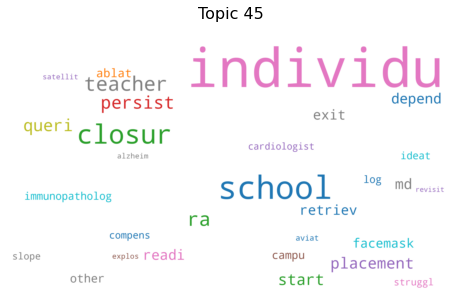

```
Keywords individu, school, closur, teacher, ra, persist, queri, start, placement, md
We aimed to investigate the confirmed COVID-19 cases among students and teachers in elementary schools (ages 6-12 years) and junior high schools (ages 13-15 years) in Japan between 1 June and 31 July 2020 We requested all schools to provide reports when students or teachers tested positive for COVID…
0.33550000190734863
Social distancing mandated by COVID-19 so as to slow viral spread has resulted in school closures. It is now the end of summer 2020 and schools are starting. Reopening schools could be safe if accompanied by precautionary measures. This paper describes the events leading up to school closures in Mal…
0.2946000099182129
BACKGROUND: Duration of persistence of SARS-CoV-2 in the upper respiratory tract of infected individuals has important clinical and epidemiological implications. AIM: We aimed to establish the duration and risk factors for persistence of SARS-CoV-2 in the upper respiratory tract of asymptomatic infe…
0.25369998812675476
```

```python
show_topic(text_topic_df,44,3)
```

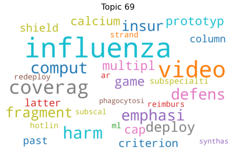

```
Keywords influenza, video, coverag, harm, comput, emphasi, defens, insur, fragment, deploy
Watch a video of this article
0.3366999924182892
BACKGROUND: The current 2019 novel coronavirus outbreak is rapidly evolving. YouTube has been recognized as a popular source of information in previous disease outbreaks. We analyzed the content on YouTube about n-CoV in English and Mandarin languages. METHODS: YouTube was searched using the terms '…
0.33320000767707825
BACKGROUND: The current 2019 novel coronavirus outbreak is rapidly evolving. YouTube has been recognized as a popular source of information in previous disease outbreaks. We analyzed the content on YouTube about n-CoV in English and Mandarin languages. METHODS: YouTube was searched using the terms '…
0.33320000767707825
Satisfiability checking for monotone modal logic is known to be (only) NP-complete. We show that this remains true when the logic is extended with alternation-free fixpoint operators as well as the universal modality; the resulting logic – the alternation-free monotone [Formula: see text]-calculus w…
0.3116999864578247
The graphical, hypergraphical and polymatrix games frameworks provide concise representations of non-cooperative normal-form games involving many agents. In these graph-based games, agents interact in simultaneous local subgames with the agents which are their neighbors in a graph. Recently, ordinal…
0.3059000074863434
Introduction: YouTube is an important online source of information and has two billion users globally Its viewing numbers tend to increase exponentially in extraordinary global situations Our aim in this study was to review and evaluate the contents of the most frequently viewed YouTube videos durin…
0.288100004196167
```

```python
show_topic(text_topic_df,68,6)
```

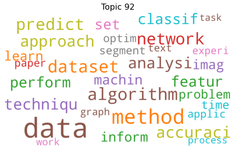

```
Keywords data, method, dataset, algorithm, predict, network, accuraci, approach, analysi, techniqu
A large amount of labelled data (absolute information) is usually needed for an ordinal classifier to attain a good performance. As shown in a recent paper by the present authors, the lack of a large amount of absolute information can be overcome by additionally considering some side information in …
0.7531999945640564
Medical image segmentation is a fundamental and challenging problem for analyzing medical images due to the approximate pixel values of adjacent tissues in boundary and the non-linear feature between pixels. Although fully convolutional neural networks such as U-Net has demonstrated impressive perfo…
0.741100013256073
In solving large scale optimization problems, CMA-ES has the disadvantages of high complexity and premature stagnation. To solve this problem, this paper proposes an improved CMA-ES, called GI-ES, for large-scale optimization problems. GI-ES uses all the historical information of the previous genera…
0.7146000266075134
```

```python
show_topic(text_topic_df,91,3)
```

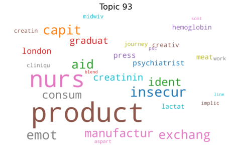

```
Keywords product, nurs, insecur, emot, capit, aid, exchang, manufactur, ident, consum
La production in vitro de plaquettes offre une opportunité de résoudre les problèmes liés aux limitations d’approvisionnement et à la sécurité des dons de produits dérivés du sang. Les cellules souches pluripotentes induites – ou iPSC – sont une source idéale pour la production de cellules à des fin…
0.336899995803833
Skilled nurses are critically important to an effective pandemic response.
0.3366999924182892
The World Needs 6 Million More Nurses: What Are We Waiting For?
0.3366999924182892
Nurses have put themselves in precarious situations by caring for COVID-19 patients. Through the grid of faith, hope, and love as depicted in 1 Corinthians, the author commends the selfless work of nurses and esteems God's faithfulness to nurses who acknowledge him.
0.3319000005722046
As the COVID-19 pandemic continues its journey around the world, it has triggered a global nursing response, with nurses everywhere working to save the lives of their extremely sick patients. In parallel with the frontline response, the International Council of Nurses, the World Health Authority and…
0.3228999972343445
The article discusses recently hosted our Annual Nurses Day at the Capitol where more than 250 Kentucky nurses and nursing students gathered to talk with legislators about issues important to all;and issue is Kentucky nurses is the growing Novel Coronavirus (NCov) epidemic
0.3084999918937683
```

```python
show_topic(text_topic_df,92,6)
```

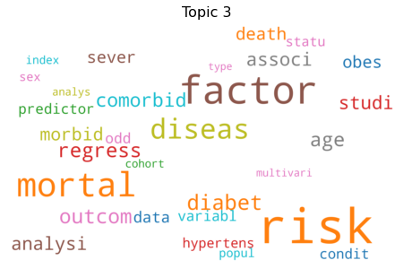

```
Keywords risk, factor, mortal, diseas, diabet, outcom, regress, age, comorbid, studi
Background: Identifying risk factors disease characteristics, severity and mortality of COVID-19 are poorly clear, particularly in Egypt brbrObjectives:
0.8586000204086304
Diabetes mellitus vormt een aanzienlijke ziektelast in Nederland; ruim 1,2 miljoen Nederlanders hebben diabetes, waarvan 90 procent type 2-diabetes. De daarmee gepaard gaande economische last wordt geschat op ruim 6,9 miljard euro. De prevalentie zal naar verwachting in de toekomst nog verder toenem…
0.7512000203132629
Abstract Background There is mounting evidence related to the association between obesity and severity of COVID-19. However, the direct relationship of the increase in the severe COVID-19 risk factors, with an increase in body mass index (BMI), has not yet been evaluated. Aim This meta-analysis aims…
0.6754000186920166
```

```python
show_topic(text_topic_df,2,3)
```

Use pyLDAvis tool to perform visualization.

```python
pyLDAvis.enable_notebook()
vis = pyLDAvis.gensim.prepare(lda_model, corpus, dictionary=dictionary,R=10,sort_topics=False)
vis
```

[interactive chart not shown]